# COMPASS Subset Magnitude Plots

Malisa Smith

version February 12, 2021

```r
library(here)
library(tidyverse)
library(ggplot2)
library(ggsignif)
library(ggbeeswarm)
library(tidyselect)
library(flowWorkspace)
library(broom)
library(grid)
library(gridExtra)
library(patchwork)
```

```r
save_output <- FALSE

# Arial font setup. Downloaded afms from https://github.com/microsoft/microsoft-r-open/tree/ec3fd89e5fb5794bd8149905c134ad801bb61800
Arial <- Type1Font(family = "Arial",
                   metrics = c(here::here("data/Arial_afm/ArialMT.afm"),
                               here::here("data/Arial_afm/ArialMT-Bold.afm"),
                               here::here("data/Arial_afm/ArialMT-Italic.afm"),
                               here::here("data/Arial_afm/ArialMT-BoldItalic.afm")))
pdfFonts(Arial = Arial)
```

Examine background-corrected magnitudes from selected COMPASS subsets.

# Read in data

```r
# Load the results from the saved calls to make_dotplot_for_COMPASS_run(), which contains the pre-calculated background-corrected magnitudes for subsets which passed the mean_gamma threshold filter. This will help with the "IFNg+ vs IFNg- COMPASS subset" plots
bg_corr_dotplots <- readRDS(here::here("processed_data/20200824_make_dotplot_for_COMPASS_run_list.rds"))
CD4RunNames <- c("4_Spike_1", "4_Spike_2", "4_NCAP", "4_VEMP")
CD8RunNames <- c("8_Spike_1", "8_Spike_2", "8_NCAP", "8_VEMP")

# And load the GatingSet. We can extract the data for the rest ofthe ploots from this.
gsPath <- here::here("out/GatingSets/20200815_HAARVI_ICS_GatingSet_AllBatches_with_COMPASS_Subsets_R4.0.3")
gs <- load_gs(gsPath)
```

# IFNg+ vs IFNg- COMPASS subset magnitudes

Aggregate the background-corrected magnitudes of all the IFNg+ COMPASS subsets and compare the expression to the aggregated IFNg- subsets. Do this per stim. For CD4, and then for CD8. Exclude healthies.

It’s easiest to extract this from the output of `make_dotplot_for_COMPASS_run()` because it pre-filtered the COMPASS subsets. The list is already filtered for non-healthies and just individuals which were run through COMPASS, and the magnitude data is filtered for COMPASS subsets which passed the mean_gamma threshold from the respective COMPASS run. The magnitudes are stored as proportions, not percents.

```r
stim_labels <- c("Spike_1"="S1", "Spike_2"="S2", "NCAP" = "N", "VEMP" = "E")
StimIFNgColors <- list("S1" = c("IFNg_Pos" = "#bd0264ac", "IFNg_Neg" = "#fd2898ac"),
                      "S2" = c("IFNg_Pos" = "#fca654ac", "IFNg_Neg" = "#fedab8ac"),
                      "N" = c("IFNg_Pos" = "#a38dc2ac", "IFNg_Neg" = "#d9cfe6ac"),
                      "E" = c("IFNg_Pos" = "#d4d41bac", "IFNg_Neg" = "#ecec69ac"))
StimIFNgOutlineColors <- list("S1" = c("IFNg_Pos" = "#bd0264df", "IFNg_Neg" = "#fd2898df"),
                      "S2" = c("IFNg_Pos" = "#fca654df", "IFNg_Neg" = "#fedab8df"),
                      "N" = c("IFNg_Pos" = "#a38dc2df", "IFNg_Neg" = "#d9cfe6df"),
                      "E" = c("IFNg_Pos" = "#d4d41bdf", "IFNg_Neg" = "#ecec69df"))

plot_ifng_strat <- function(current_run, current_ylim=NA) {
  current_dat_wide <- bg_corr_dotplots[[current_run]]$BgCorrMagnitudes %>%
    mutate(IFNg_Neg = rowSums(.[grep("[!]IFNg", names(.))]),
           IFNg_Pos = rowSums(.[grep("[&]IFNg", names(.))])) %>%
    dplyr::select(Individual, IFNg_Neg, IFNg_Pos)
  current_dat_long <- current_dat_wide %>%
    pivot_longer(cols = c("IFNg_Neg", "IFNg_Pos"),
                 names_to = "IFNg_Pos_or_Neg", values_to = "BgCorr_Prop_Sum") %>%
    mutate(IFNg_Pos_or_Neg = factor(IFNg_Pos_or_Neg, levels = c("IFNg_Pos", "IFNg_Neg")),
           BgCorr_Prop_Sum_zeroed = ifelse(BgCorr_Prop_Sum > 0, BgCorr_Prop_Sum, 0))

  current_signed_rank_test <- wilcox.test(current_dat_wide$IFNg_Neg, current_dat_wide$IFNg_Pos, paired=T)
  p.text <- if(current_signed_rank_test$p.value < 0.001) { "p<0.001"} else {
    paste0("p=", round(current_signed_rank_test$p.value, 3)) }

  current_coreceptor <- paste0("CD", sub("([0-9])_.*", "\\1", current_run))
  current_stim <- stim_labels[[sub("[0-9]_(.*)", "\\1", current_run)]]

  # The data is paired, but the violin plot shows the density better than a line plot
  # geom_line(aes(group=Individual), color="grey")
  current_plot <- ggplot(current_dat_long, aes(IFNg_Pos_or_Neg, BgCorr_Prop_Sum_zeroed)) +
    theme_bw(base_size = 22) +
    geom_hline(yintercept = 0, linetype="dashed", alpha = 0.5) +
    geom_violin(aes(fill = IFNg_Pos_or_Neg), draw_quantiles = c(0.5),
                # All violins have the same maximum width. Overrides default of equal area
                scale="width", width = 0.6) +
    geom_violin(fill="transparent", draw_quantiles = c(0.25, 0.75), linetype = "dashed",
                scale="width", width = 0.6) +
    geom_violin(aes(color=IFNg_Pos_or_Neg), fill="transparent",
              scale="width", width=0.6, size=1.1) +
    geom_quasirandom(size=0.1, width=0.2, varwidth=T, method="quasirandom") +
    theme(axis.title.x = element_blank(),
            axis.title.y = element_text(size=20),
            axis.text.y = element_text(color="black", size=17),
            axis.text.x = element_text(color="black", size=17),
            plot.title = element_text(hjust = 0.5, size=21),
            panel.grid = element_blank(),
            legend.position = "none",
            plot.margin = margin(0.3, 0.2, 0.1, 0.2, "cm")) +
    scale_y_continuous(labels = function(x) paste0(x*100)) +
    scale_x_discrete(labels=c("IFNg_Pos" = "IFN-\u03B3+", "IFNg_Neg" = "IFN-\u03B3-"),
                       expand = c(0.3, 0.3)) +
    labs(y = sprintf("Cytokine+\n(%% %s)", current_coreceptor),
         title = current_stim) +
    scale_fill_manual(values = StimIFNgColors[[current_stim]]) +
    scale_color_manual(values = StimIFNgOutlineColors[[current_stim]])

  if(is.na(current_ylim)) {
    plot_ylims <- ggplot_build(current_plot)$layout$panel_params[[1]]$y.range

    current_plot <- current_plot +
      annotate("text", x = 1.5, y = plot_ylims[2] + 0.01*diff(plot_ylims), label = p.text, size=5.5)

    plot_ylims <- ggplot_build(current_plot)$layout$panel_params[[1]]$y.range
    plot_ylims[[2]] <- plot_ylims[2] + 0.01*diff(plot_ylims)

    current_plot <- current_plot + coord_cartesian(ylim = plot_ylims)
  } else {
    current_plot <- current_plot +
      coord_cartesian(ylim = current_ylim) +
      annotate("text", x = 1.5, y = current_ylim[2] - 0.05*diff(current_ylim), label = p.text, size=5.5)
  }

  list("plot" = current_plot,
       "test_result" = current_signed_rank_test,
       "data_long" = current_dat_long)
}

# There are a couple really high outliers. Exclude them:

# Patient 13 has high IFNg_Neg CD8 Spike 2 response, at 0.0199
# Next highest is 0.00427
bg_corr_dotplots$`8_Spike_2`$BgCorrMagnitudes %>%
    mutate(IFNg_Neg = rowSums(.[grep("[!]IFNg", names(.))]),
           IFNg_Pos = rowSums(.[grep("[&]IFNg", names(.))])) %>%
    dplyr::select(Individual, IFNg_Neg, IFNg_Pos) %>% arrange(-IFNg_Neg) %>% head()
```

```
## # A tibble: 6 x 3
##   Individual IFNg_Neg IFNg_Pos
##   <chr>         <dbl>    <dbl>
## 1 13          0.0199         0
## 2 128C        0.00427        0
## 3 147C        0.00386        0
## 4 36C         0.00380        0
## 5 142C        0.00338        0
## 6 150C        0.00336        0
```

```r
# Patient 15530 has high IFNg_Pos CD8 NCAP response, at 0.0361
# Next highest is 0.00479
bg_corr_dotplots$`8_NCAP`$BgCorrMagnitudes %>%
    mutate(IFNg_Neg = rowSums(.[grep("[!]IFNg", names(.))]),
           IFNg_Pos = rowSums(.[grep("[&]IFNg", names(.))])) %>%
    dplyr::select(Individual, IFNg_Neg, IFNg_Pos) %>% arrange(-IFNg_Pos) %>% head()
```

```
## # A tibble: 6 x 3
##   Individual   IFNg_Neg IFNg_Pos
##   <chr>           <dbl>    <dbl>
## 1 15530       0.000751   0.0361
## 2 59C         0.000374   0.00333
## 3 80C         0.000347   0.00262
## 4 128C        0.000923   0.00175
## 5 12C        -0.000149   0.00153
## 6 157C       -0.0000612  0.00118
```

```r
ifng_stratified_output_list <- map2(.x = c(CD4RunNames, CD8RunNames),
                              .y = list(NA,NA,NA,NA,
                                        NA,c(0,0.0043),c(0,0.0049),NA),
                              .f = plot_ifng_strat)
names(ifng_stratified_output_list) <- c(CD4RunNames, CD8RunNames)

data.frame(run = names(ifng_stratified_output_list),
           p.unadj = unlist(lapply(names(ifng_stratified_output_list), function(n) {
             ifng_stratified_output_list[[n]]$test_result$p.value
           }))) %>%
  mutate(CoReceptor = ifelse(grepl("^4", run), "CD4", "CD8")) %>%
  mutate(p_signif = p.unadj < 0.05,
         p.text = if_else(p.unadj < 0.001, "p<0.001", paste0("p=", round(p.unadj, 3))))
```

```
##         run      p.unadj CoReceptor p_signif  p.text
## 1 4_Spike_1 6.188429e-02        CD4    FALSE p=0.062
## 2 4_Spike_2 1.848324e-05        CD4     TRUE p<0.001
## 3    4_NCAP 1.742637e-01        CD4    FALSE p=0.174
## 4    4_VEMP 6.890758e-11        CD4     TRUE p<0.001
## 5 8_Spike_1 7.931735e-01        CD8    FALSE p=0.793
## 6 8_Spike_2 7.530709e-05        CD8     TRUE p<0.001
## 7    8_NCAP 7.552541e-03        CD8     TRUE p=0.008
## 8    8_VEMP 3.829486e-10        CD8     TRUE p<0.001
```

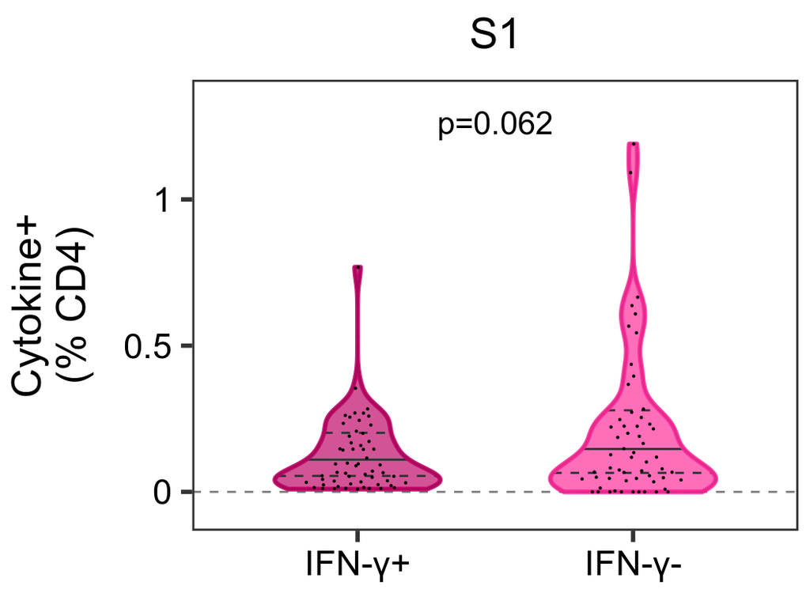

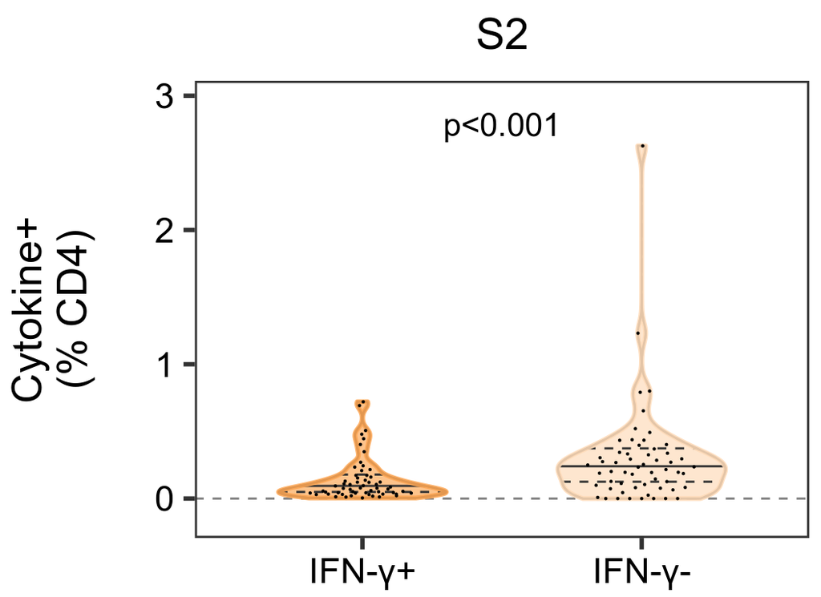

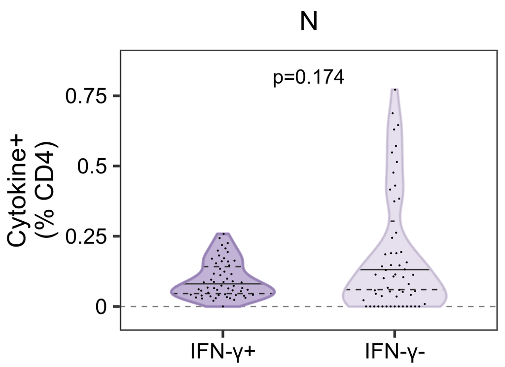

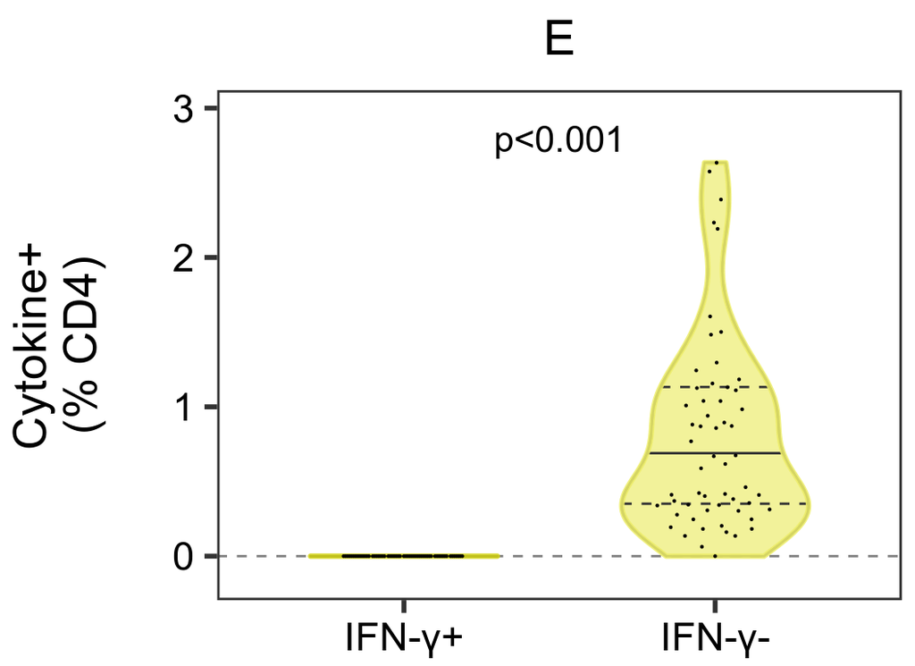

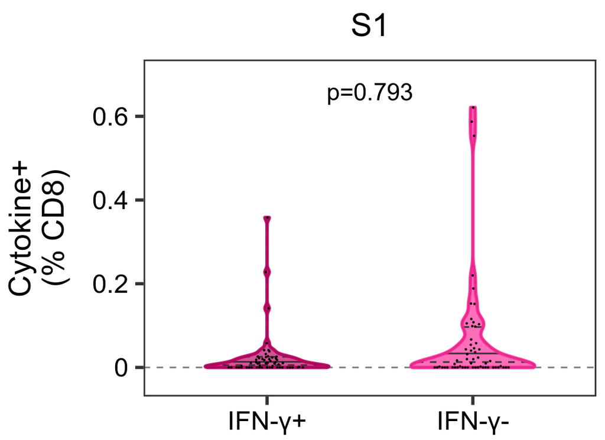

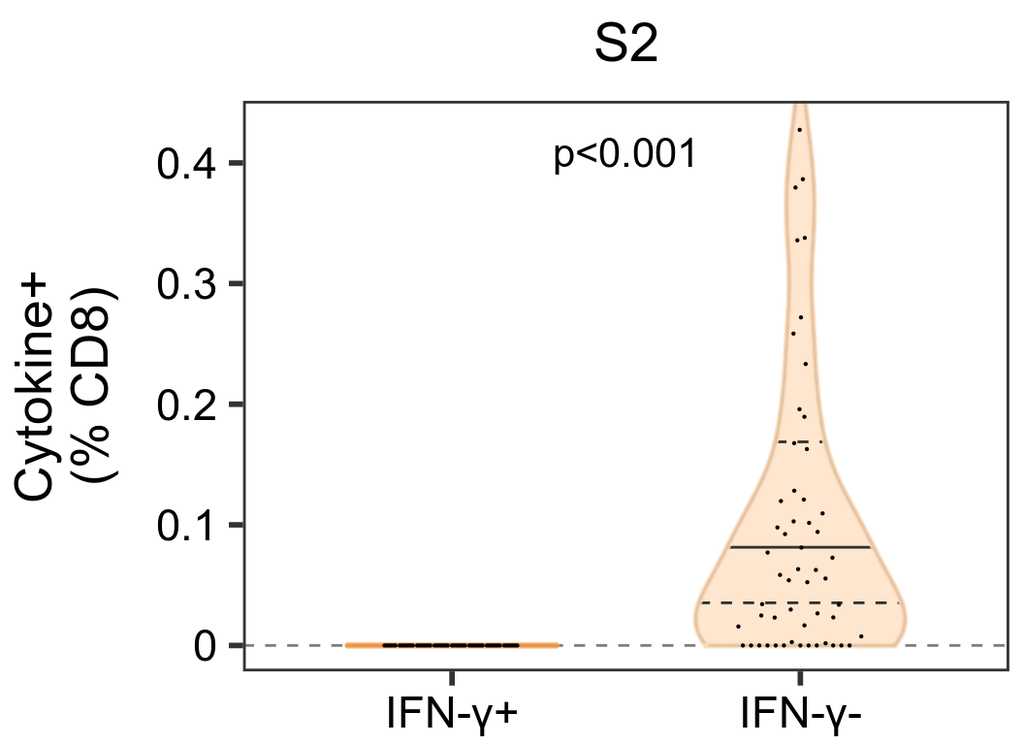

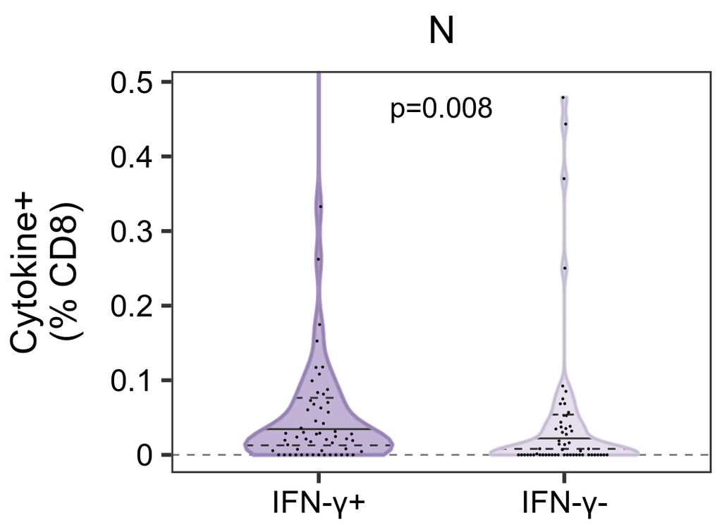

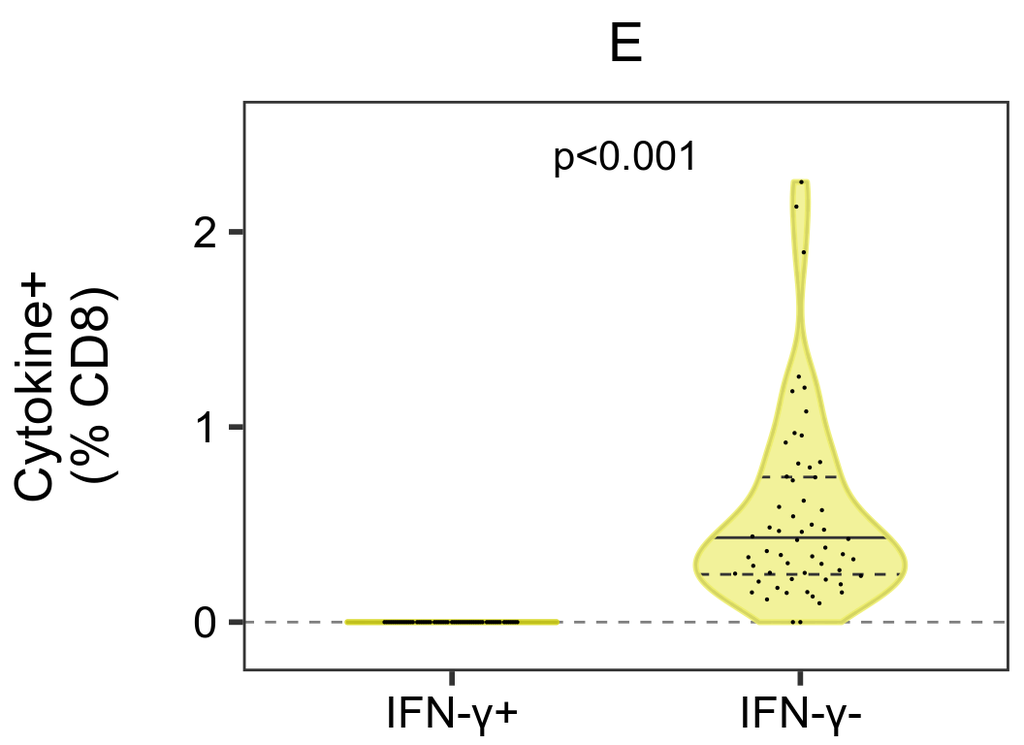

```r
# Make the width of all plots the same
# Help from here https://stackoverflow.com/a/41242871
gl <- lapply(ifng_stratified_output_list, function(l) { ggplotGrob(l$plot) })
wd <- do.call(unit.pmax, lapply(gl, "[[", 'widths')) # Grab the width of the plot which has the largest width
ifng_stratified_plots <- lapply(gl, function(x) {
  x[['widths']] = wd
  x})

# The p-values are unadjusted. Wilcoxon signed-rank tests
for(x in ifng_stratified_plots) {
  grid.arrange(x)
}
```

```r
ifng_stratified_output_list$`8_Spike_2`$data_long %>% dplyr::filter(BgCorr_Prop_Sum > 0.005)
```

```
## # A tibble: 1 x 4
##   Individual IFNg_Pos_or_Neg BgCorr_Prop_Sum BgCorr_Prop_Sum_zeroed
##   <chr>      <fct>                     <dbl>                  <dbl>
## 1 13         IFNg_Neg                 0.0199                 0.0199
```

```r
ifng_stratified_output_list$`8_NCAP`$data_long %>% dplyr::filter(BgCorr_Prop_Sum > 0.0045)
```

```
## # A tibble: 2 x 4
##   Individual IFNg_Pos_or_Neg BgCorr_Prop_Sum BgCorr_Prop_Sum_zeroed
##   <chr>      <fct>                     <dbl>                  <dbl>
## 1 15575      IFNg_Neg                0.00479                0.00479
## 2 15530      IFNg_Pos                0.0361                 0.0361
```

```r
if(save_output) {
  cairo_pdf(file=here::here("out/PostCompassPlots/Magnitude_Plots/Fig3B_CD4_IFNg_Pos_vs_Neg_Magnitudes_by_STIM.pdf"), width=7, height=7,
        onefile = TRUE, bg = "transparent", family = "Arial") # default unit is inches, default font is Helvetica.
  print((ifng_stratified_output_list$`4_Spike_1`$plot | ifng_stratified_output_list$`4_Spike_2`$plot) /
    (ifng_stratified_output_list$`4_NCAP`$plot | ifng_stratified_output_list$`4_VEMP`$plot))
  dev.off()

  cairo_pdf(file=here::here("out/PostCompassPlots/Magnitude_Plots/Fig5B_CD8_IFNg_Pos_vs_Neg_Magnitudes_by_STIM.pdf"), width=14, height=3.5,
        onefile = TRUE, bg = "transparent", family = "Arial") # default unit is inches, default font is Helvetica.
  print(ifng_stratified_output_list$`8_Spike_1`$plot | ifng_stratified_output_list$`8_Spike_2`$plot |
    ifng_stratified_output_list$`8_NCAP`$plot | ifng_stratified_output_list$`8_VEMP`$plot)
  dev.off()
}
```

# Compare magnitudes of selected subsets across stims

These data needs to be extracted from the GatingSet because the `make_dotplot_for_COMPASS_run()` only contains magnitude information for the subsets which were picked up by COMPASS for the respective stim. e.g. The data for CD4 Spike 1 do not include magnitudes for the subset which expresses only CD107a

CD4+  
IFNG+ CD154+TNF+IL2+  
IFNG- CD154+TNF+IL2+  
CD107a+ (others neg)

CD8+  
CD107a+ (others neg)

Make sure to subset to the individuals which got run through COMPASS. Also, exclude the healthies.  
Note that all of the selected subset magnitudes were previously found to be statistically significantly different across the 4 stims (see script 10_*), so now we perform post-hoc wilcoxon-signed rank tests.

## CD4 subsets

```r
gs_cd4 <- subset(gs, !(`SAMPLE ID` %in% c("37C", "BWT23", "116C", "BWT22")) &
                !(`SAMPLE ID` == "551432" & STIM == "Spike 2") &
                  Cohort %in% c("Non-hospitalized", "Hospitalized"))

cd4_booleanSubsets_gate_names <- c(
  "CD4_107a_AND_NOT_154_AND_NOT_IFNG_AND_NOT_IL17_AND_NOT_IL2_AND_NOT_IL4513_AND_NOT_TNF",
  "CD4_NOT_107a_AND_154_AND_NOT_IFNG_AND_NOT_IL17_AND_IL2_AND_NOT_IL4513_AND_TNF",
  "CD4_NOT_107a_AND_154_AND_IFNG_AND_NOT_IL17_AND_IL2_AND_NOT_IL4513_AND_TNF")

cd4_dat <- gs_pop_get_count_with_meta(gs_cd4, subpopulations = c("4+", tidyselect::all_of(cd4_booleanSubsets_gate_names))) %>%
  dplyr::select(`SAMPLE ID`, Cohort, STIM, Population, Count) %>%
  pivot_wider(names_from = Population, values_from = Count) %>%
  mutate_at(vars(tidyselect::all_of(cd4_booleanSubsets_gate_names)), ~ . / `4+`) %>%
  dplyr::select(-`4+`) %>%
  pivot_longer(cols = tidyselect::all_of(cd4_booleanSubsets_gate_names), names_to = "Population", values_to = "Prop") %>%
  pivot_wider(names_from = STIM, values_from = Prop) %>%
  mutate_at(vars("VEMP", "Spike 1", "Spike 2", "NCAP"), ~ . - DMSO) %>%
  dplyr::select(-DMSO, -SEB) %>%
  pivot_longer(cols = c("VEMP", "Spike 1", "Spike 2", "NCAP"), names_to = "STIM", values_to = "BgCorrProp") %>%
  mutate(STIM = recode(STIM, "Spike 1"="S1", "Spike 2"="S2", "NCAP" = "N", "VEMP" = "E")) %>%
  rename("SAMPLE_ID" = "SAMPLE ID") %>%
  dplyr::filter(!is.na(BgCorrProp))
```

```
## Processing sample names..
```

```
## merging..
```

```
## Done
```

```r
StimColors <- c("S1" = "#f0027fac", "S2" = "#fdc086ac", "N" = "#beaed4ac", "E" = "#e6e63cac")
StimOutlineColors <- c("S1" = "#f0027fdf", "S2" = "#fdc086df", "N" = "#beaed4df", "E" = "#e6e63cdf")
plot_subset_vs_stim <- function(current_data, current_subset) {
  current_coreceptor <- sub("(CD[48])_.*", "\\1", current_subset)

  cytokine_display_text <- c("IFNG" = "IFN-\u03B3", "154" = "CD154", "TNF" = "TNF",
                  "IL2" = "IL-2", "IL4513" = "IL-4/5/13", "IL17" = "IL17a", "107a" = "CD107a")
  current_cytokines_vec <- grep("NOT_", strsplit(sub("CD[48]_(.*)", "\\1", current_subset), "_AND_")[[1]],
                                                        value = T, invert = T)
  current_subset_trunc <- paste(paste0(cytokine_display_text[names(cytokine_display_text) %in% current_cytokines_vec], "+"),
                                collapse = " ")

  current_data_for_test <- current_data %>%
    dplyr::filter(Population == current_subset) %>%
    pivot_wider(id_cols = c("SAMPLE_ID", "Cohort"), names_from = STIM, values_from = BgCorrProp) %>%
    # Remove any individuals which don't have data for all 4 stims, for the purposes of having complete data for the test
    na.omit() %>%
    # For the pairwise wilcox test, make the data long again
    pivot_longer(cols = c(S1, S2, N, E), names_to = "STIM", values_to = "BgCorrProp") %>%
    # mutate(STIM = factor(STIM, levels = c("S1", "S2", "N", "E"))) %>%
    # It should already be in order, but make sure the SAMPLE_IDs are in the same order for each STIM
    arrange(SAMPLE_ID, STIM)
  pwt <- pairwise.wilcox.test(current_data_for_test$BgCorrProp, current_data_for_test$STIM, p.adjust.method = "bonferroni", paired = TRUE)

  # For the plot, don't filter out individuals who don't have data for all 4 stims
  # This may result in inconsistency between the test results and the plot, but it should be pretty similar
  current_data_for_plot <- current_data %>%
    dplyr::filter(Population == current_subset) %>%
    mutate(STIM = factor(STIM, levels = c("S1", "S2", "N", "E")),
           BgCorrProp_zeroed = ifelse(BgCorrProp > 0, BgCorrProp, 0))

  current_plot <- ggplot(current_data_for_plot, aes(STIM, BgCorrProp_zeroed)) +
    theme_bw(base_size = 22) +
    geom_hline(yintercept = 0, linetype="dashed", alpha = 0.5) +
    geom_violin(aes(fill = STIM), draw_quantiles = c(0.5),
            # All violins have the same maximum width. Overrides default of equal area
            scale="width", width=0.6) +
    geom_violin(fill="transparent", draw_quantiles = c(0.25, 0.75), linetype = "dashed",
                scale="width", width=0.6) +
    geom_violin(aes(color=`STIM`), fill="transparent",
              scale="width", width=0.6, size=1.1) +
    geom_quasirandom(size=0.1, width=0.2, varwidth=T, method="quasirandom") +
    theme(axis.title.x = element_blank(),
            axis.title.y = element_text(size=20),
            axis.text.y = element_text(color="black", size=17),
            axis.text.x = element_text(color="black", size=17),
            plot.title = element_text(hjust = 0.5, size=21),
            panel.grid = element_blank(),
            legend.position = "none",
            plot.margin = margin(0.3, 0.2, 0.1, 0.2, "cm")) +
    scale_y_continuous(labels = function(x) paste0(x*100)) +
    scale_x_discrete(expand = c(0.3, 0.3)) +
    labs(y = sprintf("%% Responding %s T cells", current_coreceptor),
         title = current_subset_trunc) +
    scale_fill_manual(values = StimColors) +
    scale_color_manual(values = StimOutlineColors)

  list("plot" = current_plot,
       "test_result" = pwt)
}

subset_vs_stim_output_list <- lapply(cd4_booleanSubsets_gate_names, function(x) { plot_subset_vs_stim(current_data = cd4_dat, current_subset = x) })
names(subset_vs_stim_output_list) <- cd4_booleanSubsets_gate_names
```

```r
current_subset <- cd4_booleanSubsets_gate_names[[1]]
ggplot_build(subset_vs_stim_output_list[[current_subset]]$plot)$layout$panel_params[[1]]$y.range
```

```
## [1] -0.00135175  0.02838675
```

```r
annotation_df <- broom::tidy(subset_vs_stim_output_list[[current_subset]]$test_result) %>%
  dplyr::filter(p.value < 0.05) %>%
  mutate(y_pos = c(0.0283, 0.0333, 0.0085, 0.0308, 0.006, 0.0035),
         p.text = if_else(p.value < 0.001, "p<0.001", paste0("p=", round(p.value, 3))))
cd4_cd107a_plot <- subset_vs_stim_output_list[[current_subset]]$plot +
  coord_cartesian(ylim = c(NA, 0.035)) +
  suppressWarnings(ggsignif::geom_signif(inherit.aes=F,data=annotation_df,
                        aes_string(xmin="group1", xmax="group2", annotations="p.text", y_position="y_pos"),
                        tip_length = c(0.005, 0.005),
                        textsize=4.5,
                        manual = TRUE))

current_subset <- cd4_booleanSubsets_gate_names[[2]]
ggplot_build(subset_vs_stim_output_list[[current_subset]]$plot)$layout$panel_params[[1]]$y.range
```

```
## [1] -0.0004386344  0.0092113233
```

```r
annotation_df <- broom::tidy(subset_vs_stim_output_list[[current_subset]]$test_result) %>%
  dplyr::filter(p.value < 0.05) %>%
  mutate(y_pos = c(0.0046, 0.0092, 0.0066),
         p.text = if_else(p.value < 0.001, "p<0.001", paste0("p=", round(p.value, 3))))
cd4_154_il2_tnf_plot <- subset_vs_stim_output_list[[current_subset]]$plot +
  coord_cartesian(ylim = c(NA, 0.01)) +
  suppressWarnings(ggsignif::geom_signif(inherit.aes=F,data=annotation_df,
                        aes_string(xmin="group1", xmax="group2", annotations="p.text", y_position="y_pos"),
                        tip_length = c(0.005, 0.005),
                        textsize=4.5,
                        manual = TRUE))

current_subset <- cd4_booleanSubsets_gate_names[[3]]
ggplot_build(subset_vs_stim_output_list[[current_subset]]$plot)$layout$panel_params[[1]]$y.range
```

```
## [1] -0.0003389076  0.0071170598
```

```r
annotation_df <- broom::tidy(subset_vs_stim_output_list[[current_subset]]$test_result) %>%
  dplyr::filter(p.value < 0.05) %>%
  mutate(y_pos = c(0.002, 0.0094, 0.0078, 0.0086, 0.007),
         p.text = if_else(p.value < 0.001, "p<0.001", paste0("p=", round(p.value, 3))))
cd4_ifng_154_il2_tnf_plot <- subset_vs_stim_output_list[[current_subset]]$plot +
  coord_cartesian(ylim = c(NA, 0.0097)) +
  suppressWarnings(ggsignif::geom_signif(inherit.aes=F,data=annotation_df,
                        aes_string(xmin="group1", xmax="group2", annotations="p.text", y_position="y_pos"),
                        tip_length = c(0.005, 0.005),
                        textsize=4.5,
                        manual = TRUE)) +
  theme(plot.title = element_text(hjust = 0.5, size=18))
```

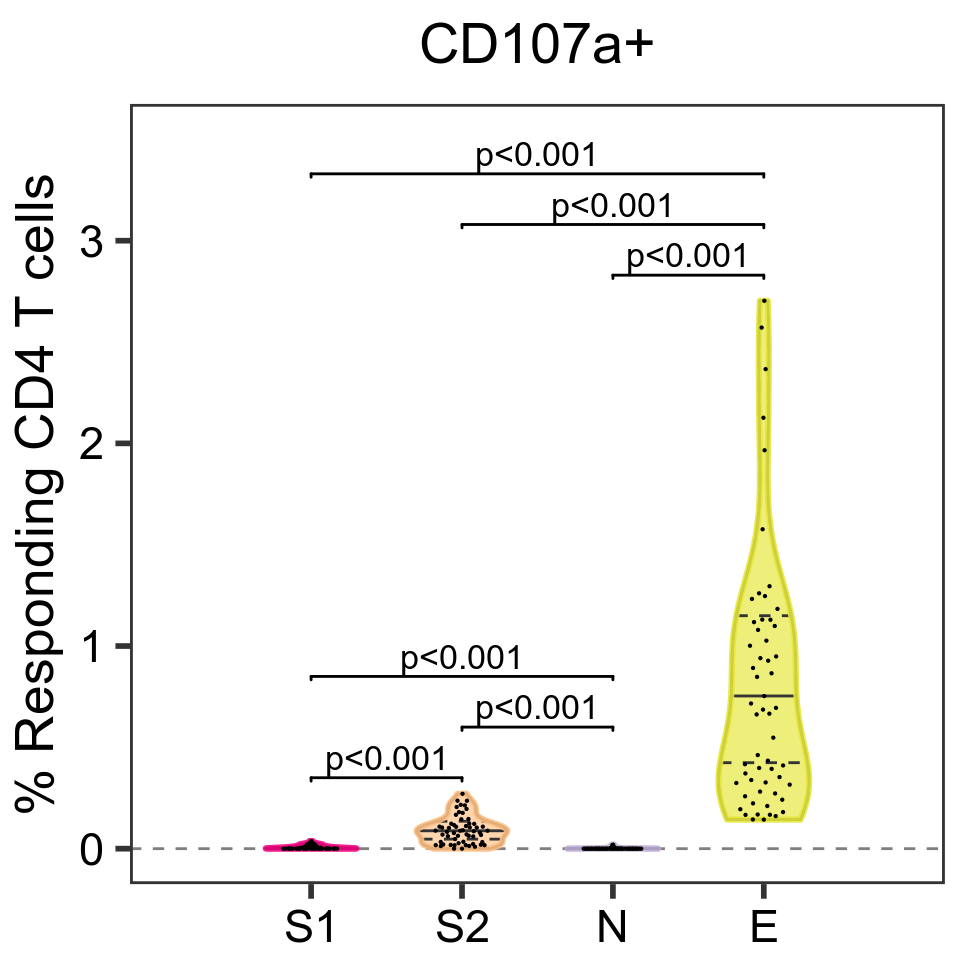

```r
cd4_cd107a_plot
```

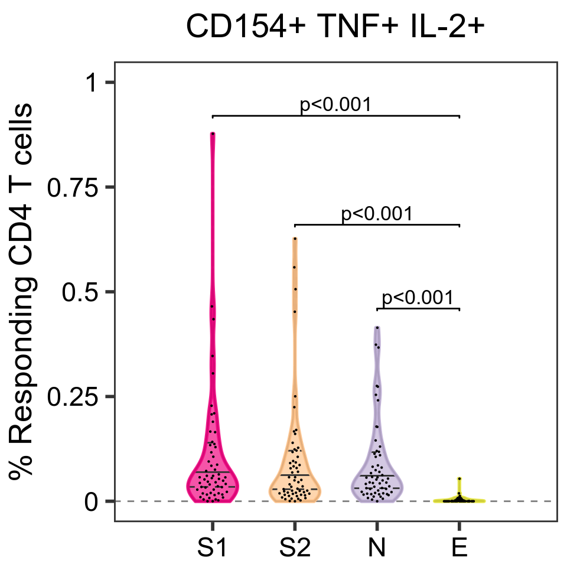

```r
cd4_154_il2_tnf_plot
```

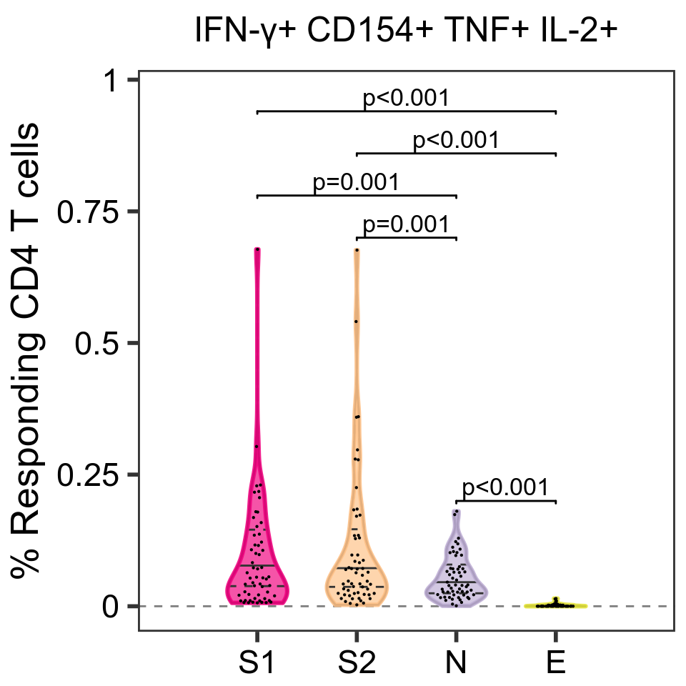

```r
cd4_ifng_154_il2_tnf_plot
```

## CD8 subsets

```r
# Drop certain wells for just the CD8 runs due to low CD8 count:
gs_cd8 <- subset(gs_cd4, !(STIM %in% c("Spike 2", "NCAP") & `SAMPLE ID` %in% c("BWT20", "15548")) &
         !(STIM == "Spike 2" & `SAMPLE ID` == "15530"))

cd8_booleanSubset_gate_name <- "CD8_107a_AND_NOT_154_AND_NOT_IFNG_AND_NOT_IL17_AND_NOT_IL2_AND_NOT_IL4513_AND_NOT_TNF"

cd8_dat <- gs_pop_get_count_with_meta(gs_cd8, subpopulations = c("8+", cd8_booleanSubset_gate_name)) %>%
  dplyr::select(`SAMPLE ID`, Cohort, STIM, Population, Count) %>%
  pivot_wider(names_from = Population, values_from = Count) %>%
  mutate_at(vars(all_of(cd8_booleanSubset_gate_name)), ~ . / `8+`) %>%
  dplyr::select(-`8+`) %>%
  pivot_longer(cols = all_of(cd8_booleanSubset_gate_name), names_to = "Population", values_to = "Prop") %>%
  pivot_wider(names_from = STIM, values_from = Prop) %>%
  mutate_at(vars("VEMP", "Spike 1", "Spike 2", "NCAP"), ~ . - DMSO) %>%
  dplyr::select(-DMSO, -SEB) %>%
  pivot_longer(cols = c("VEMP", "Spike 1", "Spike 2", "NCAP"), names_to = "STIM", values_to = "BgCorrProp") %>%
  mutate(STIM = recode(STIM, "Spike 1"="S1", "Spike 2"="S2", "NCAP" = "N", "VEMP" = "E")) %>%
  rename("SAMPLE_ID" = "SAMPLE ID") %>%
  dplyr::filter(!is.na(BgCorrProp))
```

```
## Processing sample names..
```

```
## merging..
```

```
## Done
```

```r
cd8_subset_vs_stim_out <- plot_subset_vs_stim(current_data = cd8_dat, current_subset = cd8_booleanSubset_gate_name)

current_subset <- cd8_booleanSubset_gate_name
ggplot_build(cd8_subset_vs_stim_out$plot)$layout$panel_params[[1]]$y.range
```

```
## [1] -0.001345802  0.028261846
```

```r
annotation_df <- broom::tidy(cd8_subset_vs_stim_out$test_result) %>%
  dplyr::filter(p.value < 0.05) %>%
  mutate(y_pos = c(0.0281, 0.0339, 0.0092, 0.031, 0.0063, 0.0034),
         p.text = if_else(p.value < 0.001, "p<0.001", paste0("p=", round(p.value, 3))))
cd8_107_plot <- cd8_subset_vs_stim_out$plot +
  coord_cartesian(ylim = c(NA, 0.035)) +
  suppressWarnings(ggsignif::geom_signif(inherit.aes=F,data=annotation_df,
                        aes_string(xmin="group1", xmax="group2", annotations="p.text", y_position="y_pos"),
                        tip_length = c(0.005, 0.005),
                        textsize=4.5,
                        manual = TRUE))
```

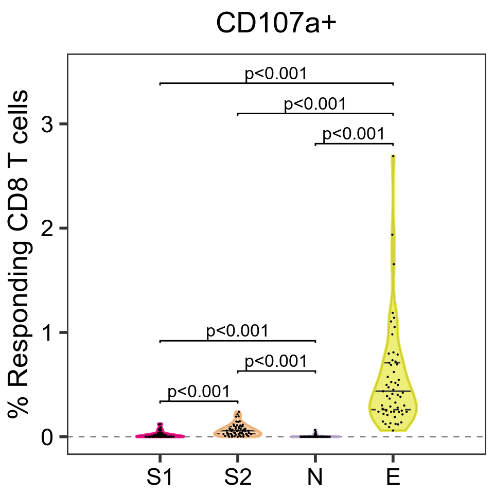

```r
cd8_107_plot
```

```r
if(save_output) {
  cairo_pdf(file=here::here("out/PostCompassPlots/Magnitude_Plots/Fig3EF_CD4_Select_Magnitudes_vs_STIM.pdf"),
            width=12, height=4, onefile = TRUE, bg = "transparent", family = "Arial")
  print(cd4_ifng_154_il2_tnf_plot | cd4_154_il2_tnf_plot | cd4_cd107a_plot)
  dev.off()

  cairo_pdf(file=here::here("out/PostCompassPlots/Magnitude_Plots/Fig5E_CD8_CD107a_Magnitude_vs_STIM.pdf"), width=4, height=4,
        onefile = TRUE, bg = "transparent", family = "Arial")
  print(cd8_107_plot)
  dev.off()
}
```

# Compare magnitudes of selected subsets across hospitalization status

CD4+  
IFNG+ CD154+TNF+IL2+  
IFNG- CD154+TNF+IL2+

For S1, S2, and NCAP

This can be extracted from the output of `make_dotplot_for_COMPASS_run()`. Remember the p-values have already been bonferroni adjusted.

```r
CohortColors <- c("Hospitalized" = "#757bbcb2", "Non-hospitalized" = "#b0d2c8bf")
CohortOutlineColors <- c("Hospitalized" = "#757bbbff", "Non-hospitalized" = "#b0d1c8ff")
CohortLabs <- c("Hospitalized" = "H", "Non-hospitalized" = "NH")
plot_subset_vs_cohort <- function(current_run, current_subset) {
  current_data <- bg_corr_dotplots[[current_run]]$BgCorrMagnitudes %>% dplyr::select(Individual, Cohort, !!as.symbol(current_subset)) %>%
    mutate(BgCorr_Zeroed = ifelse(!!as.symbol(current_subset) < 0, 0, !!as.symbol(current_subset)),
           Cohort = factor(Cohort, levels = c("Hospitalized", "Non-hospitalized")))
  current_test_result <- bg_corr_dotplots[[current_run]]$Test_Results %>% dplyr::filter(BooleanSubset == current_subset)
  current_coreceptor <- paste0("CD", sub("([48])_.*", "\\1", current_run))
  current_stim <- c("Spike_1"="S1", "Spike_2"="S2", "NCAP" = "NCAP", "VEMP" = "VEMP")[[sub("[48]_(.*)", "\\1", current_run)]]

  cytokine_display_text <- c("IFNg" = "IFN-γ", "CD154" = "CD154", "TNFa" = "TNF",
                "IL2" = "IL-2", "IL4/5/13" = "IL-4/5/13", "IL17a" = "IL17a", "CD107a" = "CD107a")
  current_cytokines_vec <- as.data.frame(t(current_test_result[,c("IFNg", "IL2", "TNFa", "CD154", "CD107a", "IL4/5/13", "IL17a")])) %>%
    rownames_to_column("Cyt") %>%
    dplyr::filter(V1 == 1) %>%
    dplyr::pull(Cyt)
  current_subset_trunc <- paste(paste0(cytokine_display_text[names(cytokine_display_text) %in% current_cytokines_vec], "+"),
                                collapse = " ")

  current_plot <- ggplot(current_data, aes(Cohort, BgCorr_Zeroed)) +
    theme_bw(base_size = 22) +
      geom_hline(yintercept = 0, linetype="dashed", alpha = 0.5) +
      geom_violin(aes(fill = Cohort), draw_quantiles = c(0.5),
              # All violins have the same maximum width. Overrides default of equal area
              scale="width", width=0.6) +
      geom_violin(fill="transparent", draw_quantiles = c(0.25, 0.75), linetype = "dashed",
                  scale="width", width=0.6) +
      geom_violin(aes(color=Cohort), fill="transparent",
                scale="width", width=0.6, size=1.1) +
      geom_quasirandom(size=0.1, width=0.2, varwidth=T, method="quasirandom") +
      theme(axis.title.x = element_blank(),
              axis.title.y = element_text(size=15),
              axis.text.y = element_text(color="black", size=17),
              axis.text.x = element_text(color="black", size=20),
              plot.title = element_text(hjust = 0.5, size=21),
              plot.subtitle = element_text(hjust = 0.5, size=13),
              panel.grid = element_blank(),
              legend.position = "none",
              plot.margin = margin(0.3, 0.2, 0.1, 0.2, "cm")) +
      scale_y_continuous(labels = function(x) paste0(x*100)) +
      scale_x_discrete(labels=CohortLabs, expand = c(0.3, 0.3)) +
      labs(y = sprintf("%% Responding %s T cells", current_coreceptor),
           title = current_stim,
           subtitle = current_subset_trunc) +
      scale_fill_manual(values = CohortColors) +
      scale_color_manual(values = CohortOutlineColors)

  plot_ylims <- ggplot_build(current_plot)$layout$panel_params[[1]]$y.range
  current_plot <- current_plot +
    annotate("text", x = 1.5, y = plot_ylims[2] + 0.01*diff(plot_ylims),
             label = current_test_result[,"p.adj.text"], size=5.5) +
     coord_cartesian(ylim = c(plot_ylims[[1]], plot_ylims[[2]] + 0.09*diff(plot_ylims)))
  current_plot
}
```

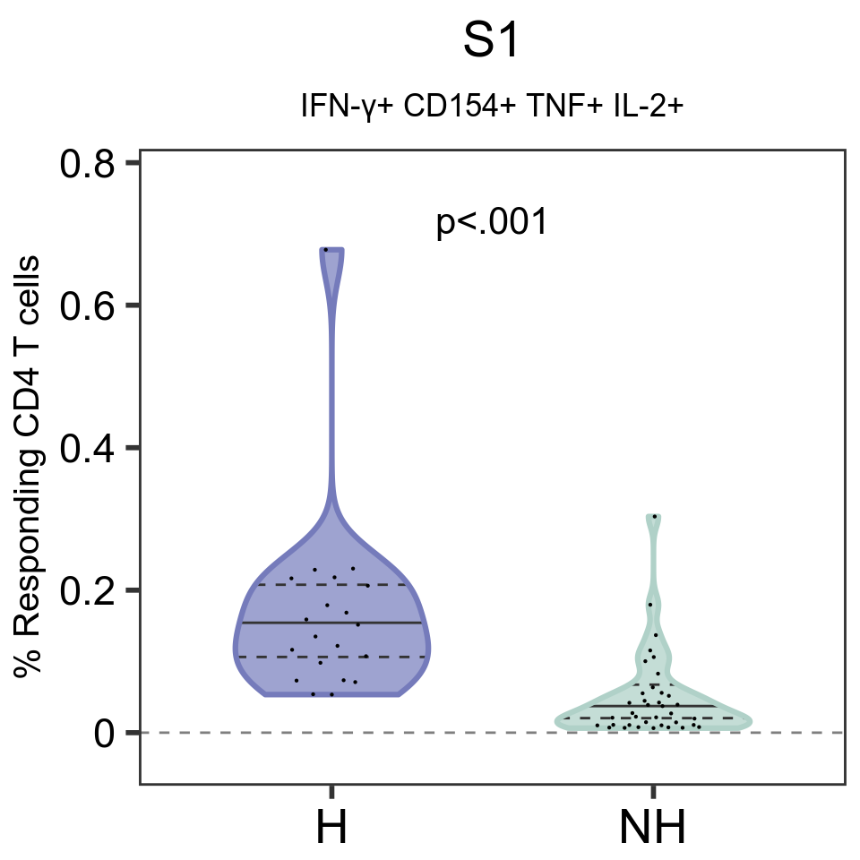

```r
cd4_s1_4func_vs_cohort <- plot_subset_vs_cohort("4_Spike_1", "IL2&!IL4/5/13&IFNg&TNFa&!IL17a&CD154&!CD107a")
cd4_s2_4func_vs_cohort <- plot_subset_vs_cohort("4_Spike_2", "IL2&!IL4/5/13&IFNg&TNFa&!IL17a&CD154&!CD107a")
cd4_n_4func_vs_cohort <- plot_subset_vs_cohort("4_NCAP", "IL2&!IL4/5/13&IFNg&TNFa&!IL17a&CD154&!CD107a")

cd4_s1_3func_vs_cohort <- plot_subset_vs_cohort("4_Spike_1", "IL2&!IL4/5/13&!IFNg&TNFa&!IL17a&CD154&!CD107a")
cd4_s2_3func_vs_cohort <-plot_subset_vs_cohort("4_Spike_2", "IL2&!IL4/5/13&!IFNg&TNFa&!IL17a&CD154&!CD107a")
cd4_n_3func_vs_cohort <- plot_subset_vs_cohort("4_NCAP", "IL2&!IL4/5/13&!IFNg&TNFa&!IL17a&CD154&!CD107a")

cd4_s1_4func_vs_cohort
```

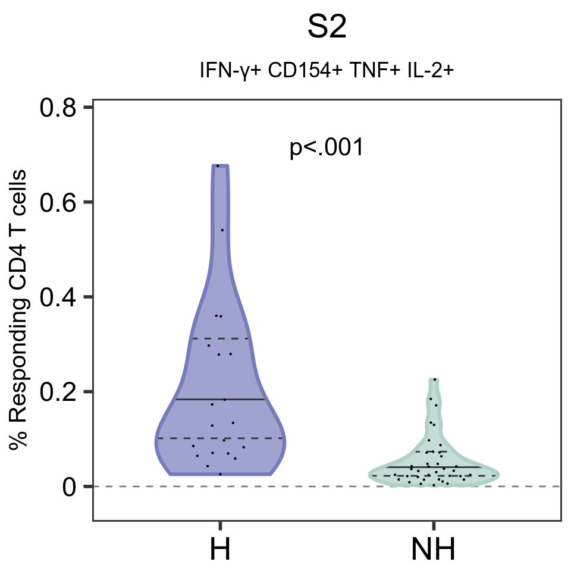

```r
cd4_s2_4func_vs_cohort
```

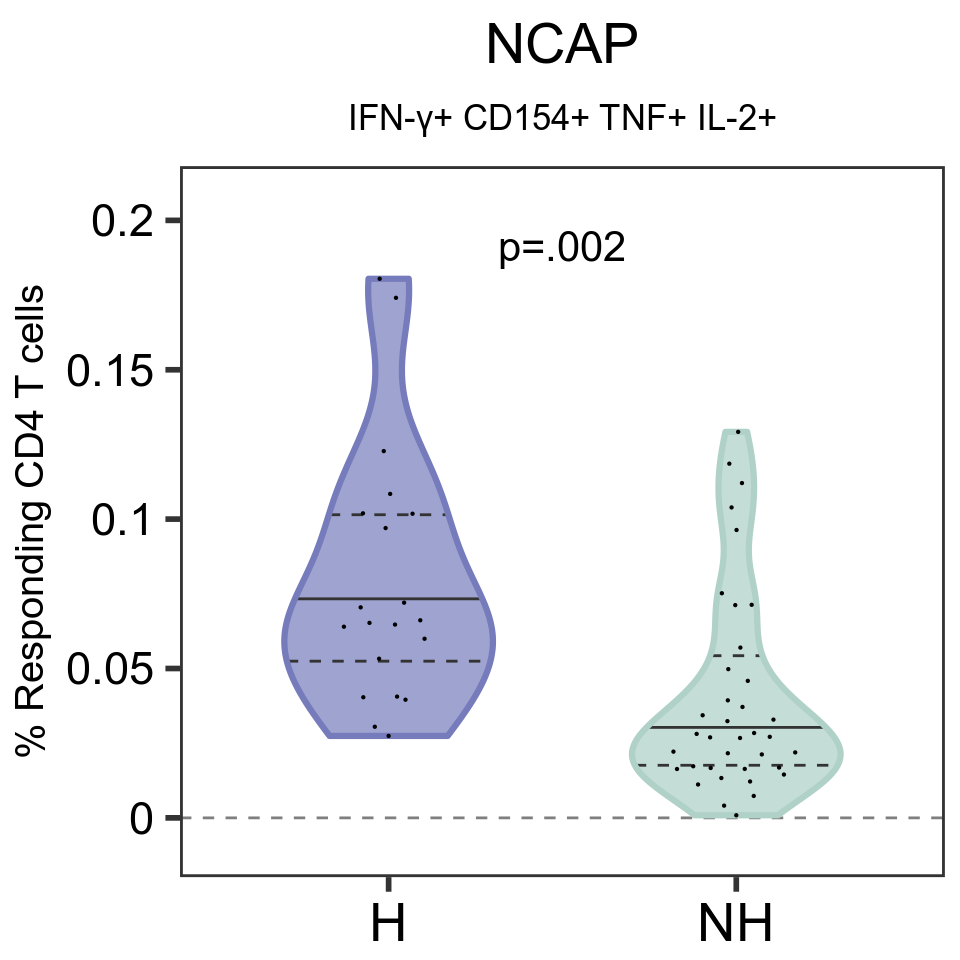

```r
cd4_n_4func_vs_cohort
```

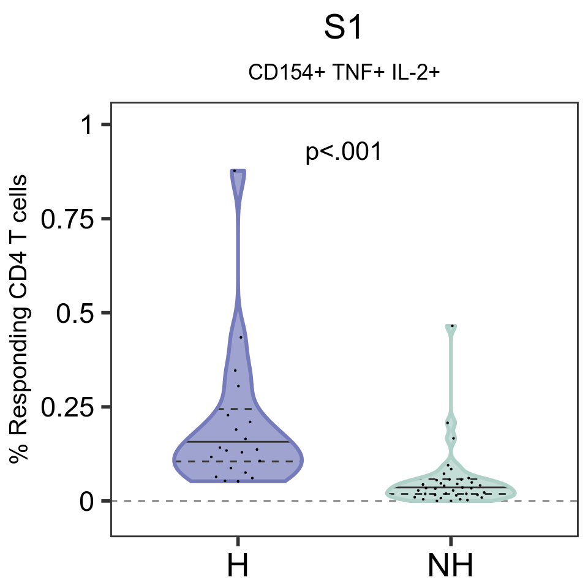

```r
cd4_s1_3func_vs_cohort
```

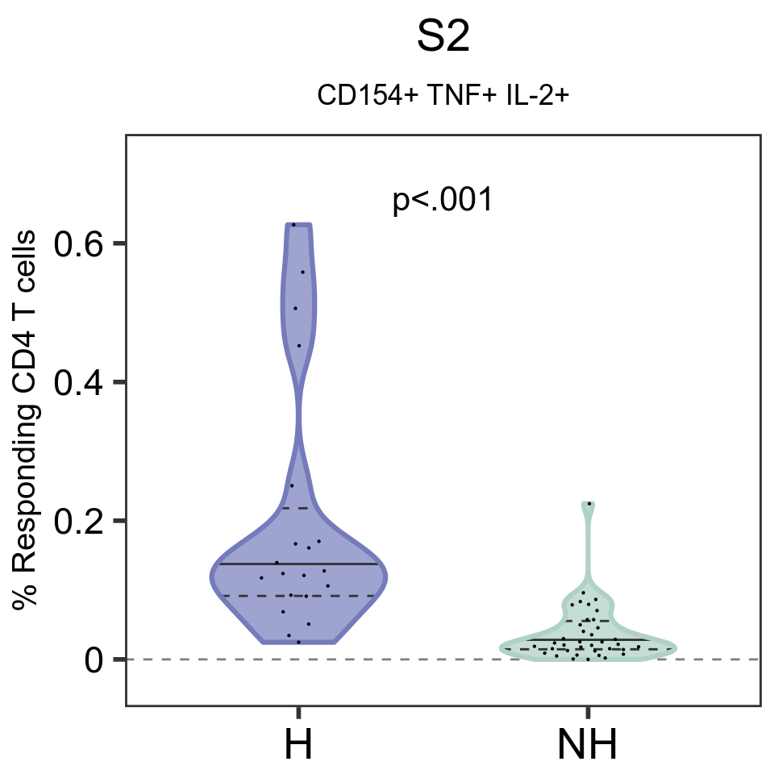

```r
cd4_s2_3func_vs_cohort
```

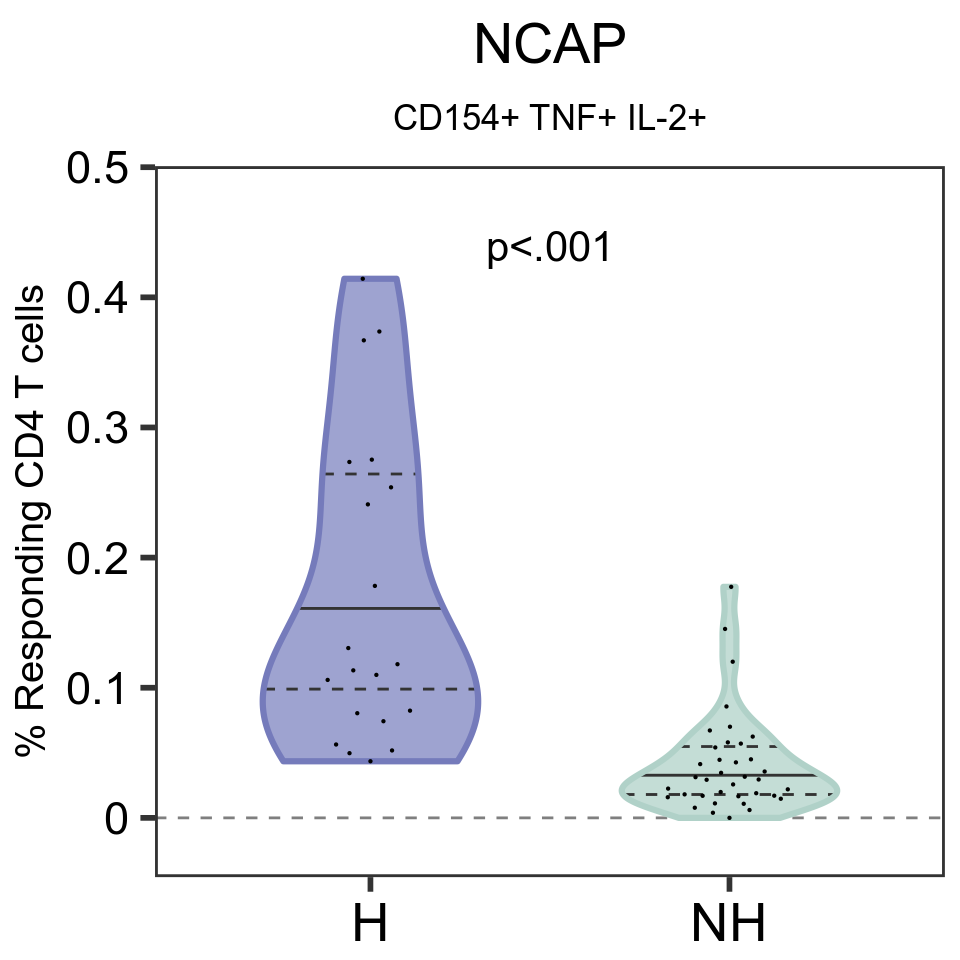

```r
cd4_n_3func_vs_cohort
```

```r
if(save_output) {
  cairo_pdf(file=here::here("out/PostCompassPlots/Magnitude_Plots/Fig4G_CD4_Select_Magnitudes_vs_Cohort.pdf"), width=6, height=9,
        onefile = TRUE, bg = "transparent", family = "Arial")
  print(((cd4_s1_4func_vs_cohort + theme(axis.title.y = element_blank())) | (cd4_s1_3func_vs_cohort) + theme(axis.title.y = element_blank())) /
    (cd4_s2_4func_vs_cohort | (cd4_s2_3func_vs_cohort + theme(axis.title.y = element_blank()))) /
    ((cd4_n_4func_vs_cohort + theme(axis.title.y = element_blank())) | (cd4_n_3func_vs_cohort) + theme(axis.title.y = element_blank())))
  dev.off()
}
```